# 12_MLPS_R_clustering_part1

Zhe Zhang (TA - Heinz CMU PhD)

3/22/2017

## Lecture 12: Clustering Part 1

Key specific tasks we covered in this lecture:

- various distance metrics
- hierarchical clustering (top-down, bottom-up, single link, complete link)
- k-means clustering

**distance metrics**. Lots of the distance metrics covered in class can be implemented on your own. If you find yourself using a more complex distance metric though, there may be R implementations available via a quick search. The `dist` function in base R includes {euclidean, maximum, manhattan, canberra, binary, minkowski}. Also, there is a `stringDist` package available, that can do various distances based on edit distance (e.g. Hamming, Damerau-Levenshtein, etc.) or others like Jaccard or Jaro-Winkler.

Another package may allow arbitrary distance functions, see here [for more](http://stackoverflow.com/questions/7524042/how-to-specify-distance-metric-while-for-kmeans-in-r).

### hierarchical clustering

In base R, there is the `hclust` command, which includes both complete, centroid, and single link hierarchical clustering. Since each element starts as its own cluster, this is bottom-up clustering.

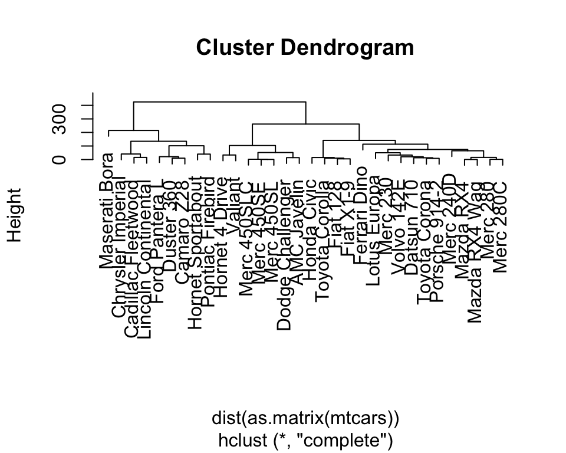

```r
cluster_result <- hclust(dist(as.matrix(mtcars)),
                         method = 'complete')
plot(cluster_result)
```

### k-means clustering

In base R, there is the `kmeans()` function. There are a few straightforward options: {`x` dataset, `centers` (number of k), and `nstart` (number of random restarts)}.

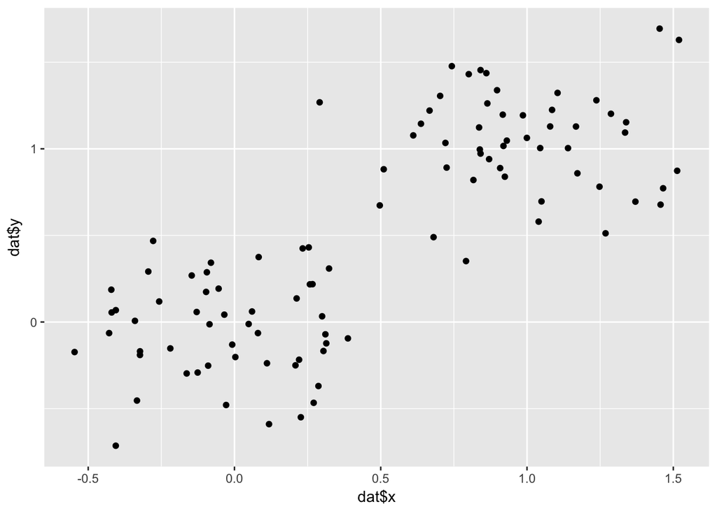

```r
library(dplyr); library(ggplot2)
# from the examples
dat <- data.frame(x = c(rnorm(50, 0, 0.3), rnorm(50, 1, 0.3)),
                  y = c(rnorm(50, 0, 0.3), rnorm(50, 1, 0.3)))
dat <- sample_n(dat, size = nrow(dat))
qplot(dat$x, dat$y)
```

```r
kmeans_result <- kmeans(dat, centers = 2, nstart = 20)
```

The kmeans output will have several useful pieces, including the identified centroids, the cluster assignments for the dataset used, the sizes of each cluster, and the various sum of squared calculations (the objective).

```r
kmeans_result
```

```
## K-means clustering with 2 clusters of sizes 50, 50
##
## Cluster means:
##             x           y
## 1 -0.02502449 -0.04058597
## 2  0.98012280  1.04305174
##
## Clustering vector:
##  48   4  42  87  26  28  99  57  46  86  56  10  97  11  83  78  68   8
##   1   1   1   2   1   1   2   2   1   2   2   1   2   1   2   2   2   1
##  52  76  14  89  75  98  37  24  73  93  59  82  33  35  16  90  13  31
##   2   2   1   2   2   2   1   1   2   2   2   2   1   1   1   2   1   1
##  95  41  71  32  64  15  23   2  55  25  61   5   9  20  53  80  74  94
##   2   1   2   1   2   1   1   1   2   1   2   1   1   1   2   2   2   2
##  21   6  18  92  62  40  51  34  36  67  91  27  12  85  44  22  60  65
##   1   1   1   2   2   1   2   1   1   2   2   1   1   2   1   1   2   2
##  45  63   1  19  66 100  50  58  81  84  49  54  96  77  17  69  39  47
##   1   2   1   1   2   2   1   2   2   2   1   2   2   2   1   2   1   1
##  88  30   7  29  43  70  79   3  72  38
##   2   1   1   1   1   2   2   1   2   1
##
## Within cluster sum of squares by cluster:
## [1] 7.190593 8.191308
##  (between_SS / total_SS =  78.0 %)
##
## Available components:
##
## [1] "cluster"      "centers"      "totss"        "withinss"
## [5] "tot.withinss" "betweenss"    "size"         "iter"
## [9] "ifault"
```